# STATS-418 HW-3

Siyuan Li, 904884144

5/24/2017

The dataset I will be delving into is the “Adult” dataset from UCI Machine Learning Repository. This dataset contains features that are associated with predicting whether annual income will exceed 50k US Dollars.

```r
### read in data
suppressMessages(data1 <- read_csv("adult.csv", col_names = FALSE))
suppressMessages(data2 <- read_csv("adult.test.csv", col_names = FALSE, na = "?"))
adult <- rbind(data1, data2); rm(data1, data2) # bind data and remove redundent data from memory
adult$X3 <- NULL; adult$X5 <- NULL # remove redundant column
names(adult) <- c("age", "workclass", "education", "marital", "occupation", "relationship", "race", "sex", "capgain", "caploss", "hpw", "ethnicity", "income")
```

```r
### check and clean for missing values
sapply(adult, function(x) sum(is.na(x)))
```

```
##          age    workclass    education      marital   occupation
##            0         2799            0            0         2809
## relationship         race          sex      capgain      caploss
##            0            0            0            0            0
##          hpw    ethnicity       income
##            0          857            0
```

```r
adult <- adult[complete.cases(adult),]
sapply(adult, function(x) sum(is.na(x))) # check again
```

```
##          age    workclass    education      marital   occupation
##            0            0            0            0            0
## relationship         race          sex      capgain      caploss
##            0            0            0            0            0
##          hpw    ethnicity       income
##            0            0            0
```

```r
### convert response variable from factor to binary
adult$income[which(adult$income == ">50K")] = 1
adult$income[which(adult$income == "<=50K")] = 0
adult$income[which(adult$income == ">50K.")] = 1
adult$income[which(adult$income == "<=50K.")] = 0
adult$income <- as.numeric(adult$income)
table(adult$income)
```

```
##
##     0     1
## 34014 11208
```

After data loading, cleaning missing rows, converting the response variable, the data shows 34014 negative cases, and 11208 positive cases.

```r
### convert categorical variable to factors
adult[,c(2:8,12)] <- lapply(adult[,c(2:8,12)], factor)
summary(adult)
```

```
##       age                   workclass            education
##  Min.   :17.00   Federal-gov     : 1406   HS-grad     :14783
##  1st Qu.:28.00   Local-gov       : 3100   Some-college: 9899
##  Median :37.00   Private         :33307   Bachelors   : 7570
##  Mean   :38.55   Self-emp-inc    : 1646   Masters     : 2514
##  3rd Qu.:47.00   Self-emp-not-inc: 3796   Assoc-voc   : 1959
##  Max.   :90.00   State-gov       : 1946   11th        : 1619
##                  Without-pay     :   21   (Other)     : 6878
##                   marital                occupation
##  Divorced             : 6297   Craft-repair   : 6020
##  Married-AF-spouse    :   32   Prof-specialty : 6008
##  Married-civ-spouse   :21055   Exec-managerial: 5984
##  Married-spouse-absent:  552   Adm-clerical   : 5540
##  Never-married        :14598   Sales          : 5408
##  Separated            : 1411   Other-service  : 4808
##  Widowed              : 1277   (Other)        :11454
##          relationship                   race           sex
##  Husband       :18666   Amer-Indian-Eskimo:  435   Female:14695
##  Not-in-family :11702   Asian-Pac-Islander: 1303   Male  :30527
##  Other-relative: 1349   Black             : 4228
##  Own-child     : 6626   Other             :  353
##  Unmarried     : 4788   White             :38903
##  Wife          : 2091
##
##     capgain         caploss             hpw                ethnicity
##  Min.   :    0   Min.   :   0.00   Min.   : 1.00   United-States:41292
##  1st Qu.:    0   1st Qu.:   0.00   1st Qu.:40.00   Mexico       :  903
##  Median :    0   Median :   0.00   Median :40.00   Philippines  :  283
##  Mean   : 1101   Mean   :  88.59   Mean   :40.94   Germany      :  193
##  3rd Qu.:    0   3rd Qu.:   0.00   3rd Qu.:45.00   Puerto-Rico  :  175
##  Max.   :99999   Max.   :4356.00   Max.   :99.00   Canada       :  163
##                                                    (Other)      : 2213
##      income
##  Min.   :0.0000
##  1st Qu.:0.0000
##  Median :0.0000
##  Mean   :0.2478
##  3rd Qu.:0.0000
##  Max.   :1.0000
##
```

The data contains 12 predictor variables and 1 response variable.

```r
### building train and test set
set.seed(1)
ntrain <- floor(0.5*nrow(adult)); ntrain
```

```
## [1] 22611
```

```r
nvalid <- floor(0.25*nrow(adult)); nvalid
```

```
## [1] 11305
```

```r
itrain <- sample(seq_len(nrow(adult)), ntrain, replace = FALSE)
train <- adult[itrain,]
Ntrain <- adult[-itrain,]
ivalid <- sample(seq_len(nrow(Ntrain)), nvalid, replace = FALSE)
valid <- Ntrain[ivalid,]
test <- Ntrain[-ivalid,]
rm(itrain, ivalid, ntrain, nvalid, Ntrain) # remove useless information from memory
```

This section of code transforms the train, validation and test set into sparse matrix, essentially preparing them for computing a logistic regression model using `glmnet`.

```r
### make sparse matrix for logistic regression
# train set
train_factors <- model.matrix(
  train$income ~
    train$workclass +
    train$education +
    train$marital +
    train$occupation +
    train$relationship +
    train$race +
    train$sex +
    train$ethnicity)[, -1]
train_sparse <- as.matrix(data.frame(train$age, train$capgain, train$caploss, train$hpw, train_factors))
rm(train_factors) # remove factor matrix from memory

# validation set
valid_factors <- model.matrix(
  valid$income ~
    valid$workclass +
    valid$education +
    valid$marital +
    valid$occupation +
    valid$relationship +
    valid$race +
    valid$sex +
    valid$ethnicity)[, -1]
valid_sparse <- as.matrix(data.frame(valid$age, valid$capgain, valid$caploss, valid$hpw, valid_factors))
rm(valid_factors) # remove factor matrix from memory

# test set
test_factors <- model.matrix(
  test$income ~
    test$workclass +
    test$education +
    test$marital +
    test$occupation +
    test$relationship +
    test$race +
    test$sex +
    test$ethnicity)[, -1]
test_sparse <- as.matrix(data.frame(test$age, test$capgain, test$caploss, test$hpw, test_factors))
rm(test_factors) # remove factor matrix from memory
```

#### Calculating model using R packages:

##### Proceed with logistic regression:

```r
### logistics regression
system.time(logistic <- glmnet(train_sparse, as.factor(train$income), alpha=1, family="binomial"))
```

```
##    user  system elapsed
##   3.090   0.015   3.110
```

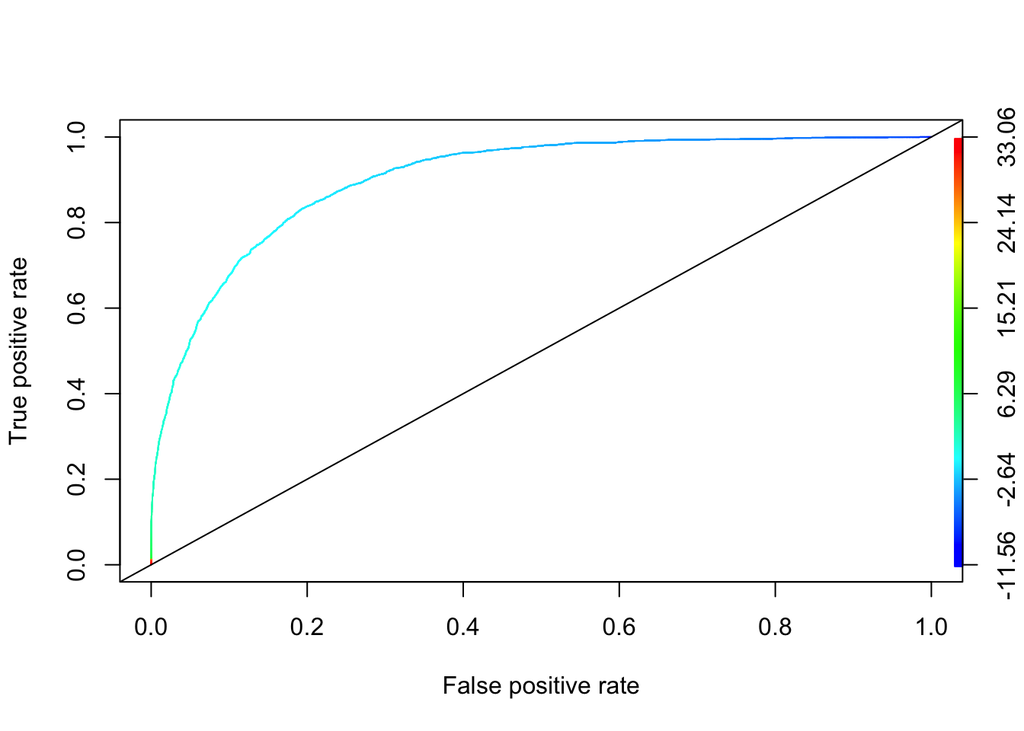

```r
roc_logit <- prediction(predict(logistic, valid_sparse)[,"s80"], valid$income)
plot(performance(roc_logit, "tpr", "fpr"), colorize = TRUE)
abline(0,1)
```

The ROC curve shows that the logistic model is a really good fit. Model Selection aims to reduce the false positive rate while imrpoving upon true positive rate, increasing the area under the curve.

```r
performance(roc_logit, "auc")@y.values[[1]]
```

```
## [1] 0.9021519
```

AUC of the untuned logistic regression model using validation set is around 0.9022.

Utilizing validation set, bootstrap with lambda value from 0 to 1 to calculate auc with each lambda. Eventually, the range is narrowed down to 0 to 0.2.

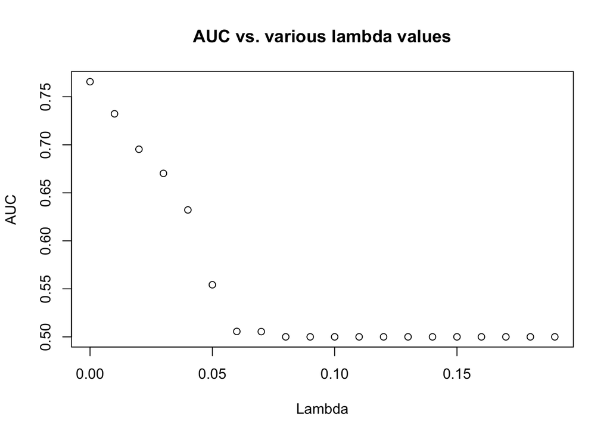

```r
lam <- seq(0, 0.19, 0.01)
vauc <- c()
for(i in 1:length(lam)){
  logit <- glmnet(train_sparse, as.factor(train$income), lambda = lam[i], alpha=1, family="binomial")
  roc_logit <- prediction(ifelse(predict(logit, valid_sparse, type = "response") > 0.5, 1, 0), valid$income)
  vauc[i] <- performance(roc_logit, "auc")@y.values[[1]]
}
plot(lam, vauc,
  xlab = "Lambda",
  ylab = "AUC",
  main = "AUC vs. various lambda values")
```

Plot shows that `lambda = 0` is the best for the model.

##### Proceed with random forest.

```r
### random forest
system.time(suppressMessages(rf <- randomForest(income ~., data = train, type = "classification", ntree = 100)))
```

```
##    user  system elapsed
##  81.289   0.517  82.181
```

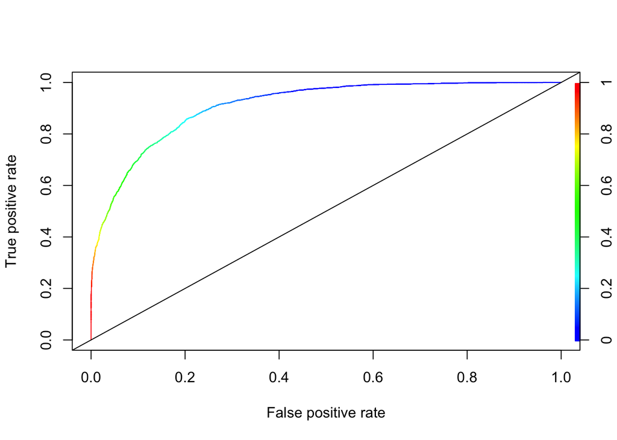

```r
roc_rf <- prediction(predict(rf, valid), valid$income)
plot(performance(roc_rf, "tpr", "fpr"), colorize = TRUE)
abline(0,1)
```

```r
performance(roc_rf, "auc")@y.values[[1]]
```

```
## [1] 0.9094739
```

AUC of the untuned random forest model using validation set is around 0.9095.

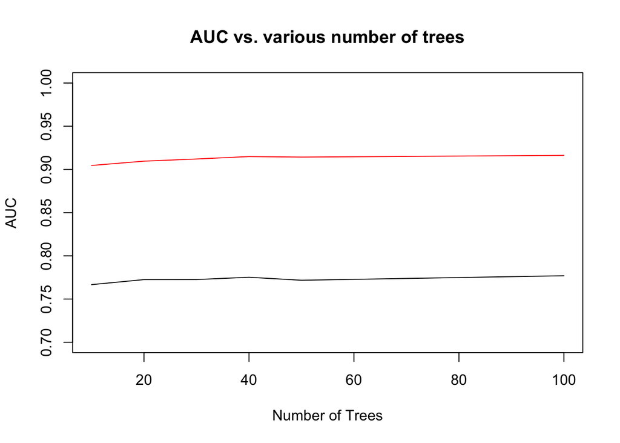

```r
tauc <- c()
vauc <- c()
ntree <- c(10, 20, 30, 40, 50, 100)
for(i in 1:length(ntree)){
  suppressMessages(bootstraprf <- randomForest(income ~., data = train, ntree = ntree[i]))
  troc_brf <- prediction(ifelse(predict(bootstraprf, train) > 0.5, 1, 0), train$income)
  vroc_brf <- prediction(ifelse(predict(bootstraprf, valid) > 0.5, 1, 0), valid$income)
  tauc[i] <- performance(troc_brf, "auc")@y.values[[1]]
  vauc[i] <- performance(vroc_brf, "auc")@y.values[[1]]
}
plot(ntree, vauc, type = "l",
  xlab = "Number of Trees",
  ylab = "AUC",
  main = "AUC vs. various number of trees",
  ylim = c(0.7, 1)); lines(ntree, tauc, type = "l", col = "red")
```

Exploring with different number of trees is significantly time consuming, the plot above shows that while training AUC stays relatively higher at around 0.9, validation set starts off around 0.75 and slowly flats out around 40 trees. Generally speaking, the more trees, the better the fit, but it is also more prune to overfitting.

##### Proceed with generalized boosted model:

```r
### generalized boosted model
system.time(boost <- gbm(income ~., data = train,
  distribution = "bernoulli",
  n.trees = 100,
  interaction.depth = 5,
  shrinkage = 0.01))
```

```
##    user  system elapsed
##   1.945   0.016   1.965
```

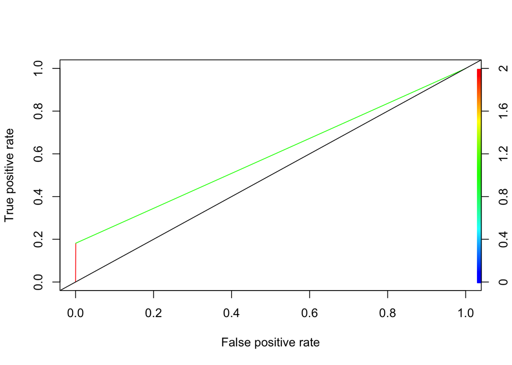

```r
roc_gbm <- prediction(ifelse(predict(boost, valid, n.trees = 100) > 0.5, 1, 0), valid$income)
plot(performance(roc_gbm, "tpr", "fpr"), colorize = TRUE)
abline(0,1)
```

```r
performance(roc_gbm, "auc")@y.values[[1]]
```

```
## [1] 0.5905607
```

Try speeding up the learning rate.

```r
### generalized boosted model
system.time(boost <- gbm(income ~., data = train,
  distribution = "bernoulli",
  n.trees = 100,
  interaction.depth = 5,
  shrinkage = 0.05))
```

```
##    user  system elapsed
##   2.090   0.019   2.112
```

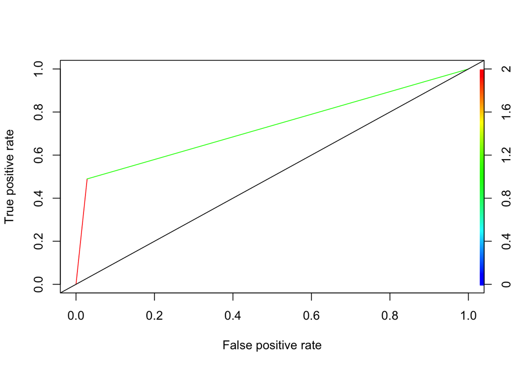

```r
roc_gbm <- prediction(ifelse(predict(boost, valid, n.trees = 100) > 0.5, 1, 0), valid$income)
plot(performance(roc_gbm, "tpr", "fpr"), colorize = TRUE)
abline(0,1)
```

We see obvious improvement in true positive rate.

```r
performance(roc_gbm, "auc")@y.values[[1]]
```

```
## [1] 0.7305415
```

By means of AUC, speeding up the learning rate improves the goodness of fit on the validation set.

Try increasing the depth of tree.

```r
### generalized boosted model
system.time(boost <- gbm(income ~., data = train,
  distribution = "bernoulli",
  n.trees = 100,
  interaction.depth = 10,
  shrinkage = 0.05))
```

```
##    user  system elapsed
##   3.427   0.015   3.445
```

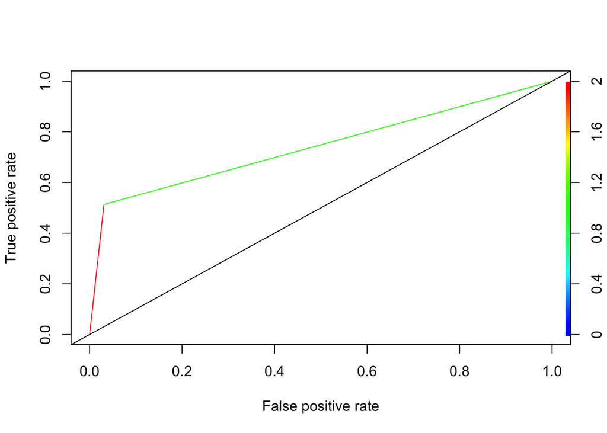

```r
roc_gbm <- prediction(ifelse(predict(boost, valid, n.trees = 100) > 0.5, 1, 0), valid$income)
plot(performance(roc_gbm, "tpr", "fpr"), colorize = TRUE)
abline(0,1)
```

We see no obvious improvement in true positive rate.

```r
performance(roc_gbm, "auc")@y.values[[1]]
```

```
## [1] 0.7412896
```

By means of AUC, increasing the depth of trees improves the goodness of fit on the validation set, but not significantly.

#### Trying the same models on h2o.ai framework:

```r
### load h2o and split train and test
h2o.init(nthreads = -1)
```

```
##  Connection successful!
##
## R is connected to the H2O cluster:
##     H2O cluster uptime:         29 minutes 27 seconds
##     H2O cluster version:        3.10.4.6
##     H2O cluster version age:    27 days
##     H2O cluster name:           H2O_started_from_R_siyuanli_exr512
##     H2O cluster total nodes:    1
##     H2O cluster total memory:   3.49 GB
##     H2O cluster total cores:    4
##     H2O cluster allowed cores:  4
##     H2O cluster healthy:        TRUE
##     H2O Connection ip:          localhost
##     H2O Connection port:        54321
##     H2O Connection proxy:       NA
##     H2O Internal Security:      FALSE
##     R Version:                  R version 3.4.0 (2017-04-21)
```

```r
dt <- as.h2o(adult)
dt[,13] <- as.factor(dt[,13])
dt_split <- h2o.splitFrame(dt, ratios = 0.75, seed = 1)
dt_train <- dt_split[[1]]
dt_test <- dt_split[[2]]
predictors <- names(dt_train)[which(names(dt_train) != "income")]
```

```r
### logistic regression
system.time({
  logit2o <- h2o.glm(x = predictors, y = "income", training_frame = dt_train, family = "binomial", alpha = 1, lambda = 0)
  })
```

```
##    user  system elapsed
##   0.151   0.004   1.224
```

```r
h2o.auc(h2o.performance(logit2o, dt_test))
```

```
## [1] 0.9047178
```

AUC of the untuned logistic regression model using test set is around 0.9047.

```r
### random forest
system.time({
  rf2o <- h2o.randomForest(x = predictors, y = "income", training_frame = dt_train, ntrees = 100)
  })
```

```
##    user  system elapsed
##   0.193   0.010   9.330
```

```r
h2o.auc(h2o.performance(rf2o, dt_test))
```

```
## [1] 0.9175853
```

```r
### generalized boosted model
system.time({
  gbm2o <- h2o.gbm(x = predictors, y = "income", training_frame = dt_train, distribution = "bernoulli", ntrees = 100, max_depth = 10, seed = 1)
  })
```

```
##    user  system elapsed
##   0.127   0.006   7.242
```

```r
h2o.auc(h2o.performance(gbm2o, dt_test))
```

```
## [1] 0.9236821
```

AUC of the untuned generalized boosted model using test set is around 0.9237.

Try early stopping on the generalized boosted model.

```r
system.time({
  gbm2oes <- h2o.gbm(x = predictors, y = "income", training_frame = dt_train, distribution = "bernoulli", max_depth = 10, seed = 1, stopping_rounds = 100, stopping_metric = "AUC")
  })
```

```
##    user  system elapsed
##   0.185   0.008   6.286
```

```r
gbm2oes
```

```
## Model Details:
## ==============
##
## H2OBinomialModel: gbm
## Model ID:  GBM_model_R_1495648691320_557
## Model Summary:
##   number_of_trees number_of_internal_trees model_size_in_bytes min_depth
## 1              50                       50              206936        10
##   max_depth mean_depth min_leaves max_leaves mean_leaves
## 1        10   10.00000        137        316   229.62000
##
##
## H2OBinomialMetrics: gbm
## ** Reported on training data. **
##
## MSE:  0.07195413
## RMSE:  0.2682427
## LogLoss:  0.231779
## Mean Per-Class Error:  0.1281413
## AUC:  0.9569273
## Gini:  0.9138546
##
## Confusion Matrix (vertical: actual; across: predicted) for F1-optimal threshold:
##            0    1    Error         Rate
## 0      23224 2329 0.091144  =2329/25553
## 1       1387 7012 0.165139   =1387/8399
## Totals 24611 9341 0.109449  =3716/33952
##
## Maximum Metrics: Maximum metrics at their respective thresholds
##                         metric threshold    value idx
## 1                       max f1  0.373837 0.790530 210
## 2                       max f2  0.178488 0.859233 288
## 3                 max f0point5  0.614922 0.822411 128
## 4                 max accuracy  0.455366 0.898062 182
## 5                max precision  0.990036 1.000000   0
## 6                   max recall  0.013657 1.000000 384
## 7              max specificity  0.990036 1.000000   0
## 8             max absolute_mcc  0.433277 0.722344 189
## 9   max min_per_class_accuracy  0.312831 0.878319 234
## 10 max mean_per_class_accuracy  0.241668 0.883689 261
##
## Gains/Lift Table: Extract with `h2o.gainsLift(<model>, <data>)` or `h2o.gainsLift(<model>, valid=<T/F>, xval=<T/F>)`
```

```r
h2o.auc(h2o.performance(gbm2oes, dt_test))
```

```
## [1] 0.9247082
```

All the models computed under h2o framework shows very high AUC, suggesting good fit to the data. It should also be noted that h2o framework is significantly more efficient in computing these models, at least for random forest model.